# Final Project

### ROC-AUC for random forest

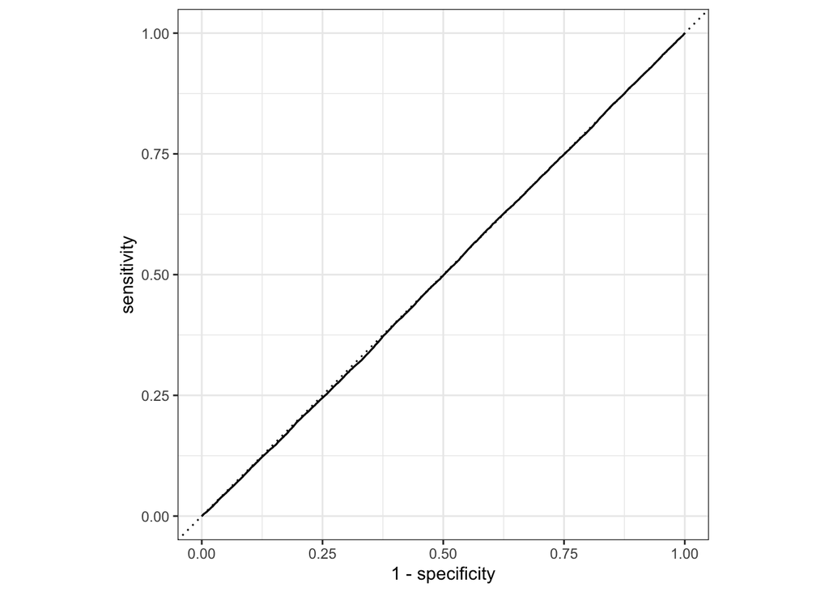

```r
auc_result2 <- roc_auc(
  rf_auc_fit2,
  truth = Heart_Attack,
  .pred_Yes,
  event_level = "second"
)
rf_auc_fit2 %>%
  roc_curve(truth = Heart_Attack, .pred_Yes) %>%
  autoplot()
```

### Selecting the best model

```r
final_modelRFU <- finalize_model(
                  rf_model,
                  rf_best2
                )

final_modelRFU
```

```
## Random Forest Model Specification (classification)
##
## Main Arguments:
##   mtry = 5
##   trees = 100
##   min_n = 5
##
## Engine-Specific Arguments:
##   num.threads = cores
##
## Computational engine: ranger
```

### Variable Importance

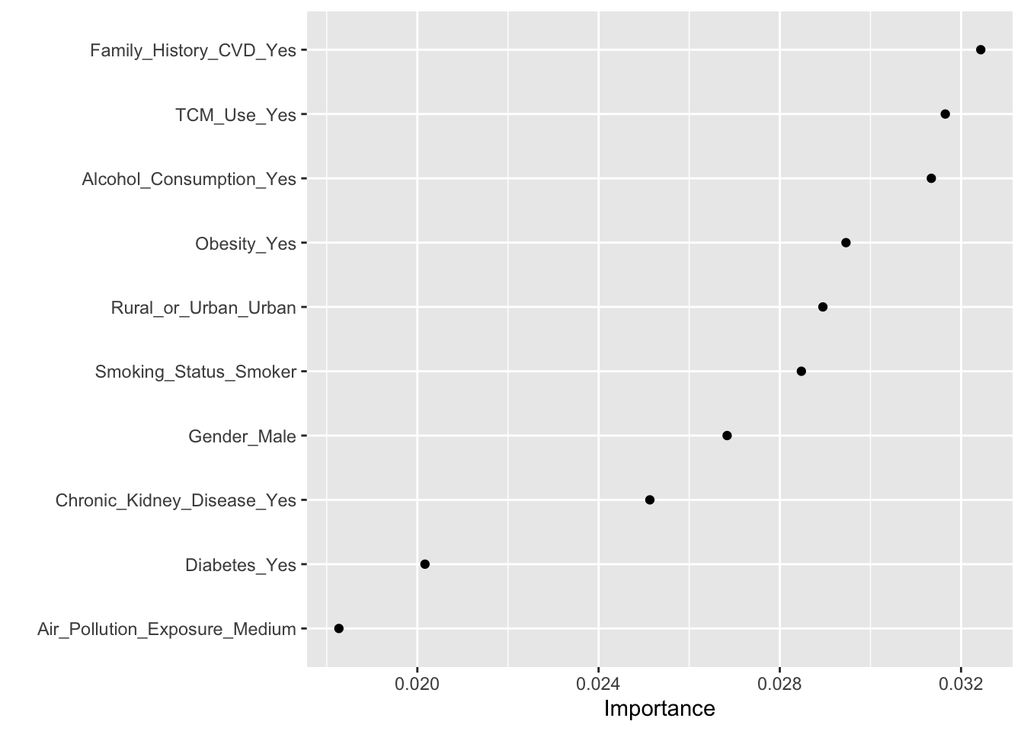

```r
tree_prep2 <- prep(Heart_rec_oversamp_rf2)

final_modelRFU %>%
  set_engine("ranger", importance = "permutation") %>%
  fit(Heart_Attack ~ .,
    data = juice(tree_prep2)) %>%
  vip(geom = "point")
```

### Fitting the final model using the optimal hyperparameters and testing the peformance on testing data

```r
final_rfu_workflow <- workflow() %>%
                      add_recipe(Heart_rec_oversamp_rf2) %>%
                      add_model(final_modelRFU)

final_resultsRFU <- final_rfu_workflow %>%
                    last_fit(data_split)

final_resultsRFU %>%
  collect_metrics()
```

```
## # A tibble: 3 × 4
##   .metric     .estimator .estimate .config
##   <chr>       <chr>          <dbl> <chr>
## 1 accuracy    binary         0.878 pre0_mod0_post0
## 2 roc_auc     binary         0.497 pre0_mod0_post0
## 3 brier_class binary         0.112 pre0_mod0_post0
```

### Collecting the predictions

```r
rfu_predictions <- final_resultsRFU %>%
  collect_predictions()
```

### Confusion matrix based on testing dataset

```r
rfu_predictions %>%
  conf_mat(truth = Heart_Attack, estimate = .pred_class)
```

```
##           Truth
## Prediction    No   Yes
##        No  63057  8722
##        Yes     2     0
```

### Metrics for Random forest based on testing data

```r
metricsRFU <- metric_set(accuracy, sens, spec, precision, recall, f_meas)

all_metrics_RFU <- metricsRFU(rf_predictions,
               truth = Heart_Attack,
               estimate = .pred_class, event_level = "second")
kable(all_metrics_RFU)
```

[output not shown]

### ROC-AUC for random forest based on testing dataset

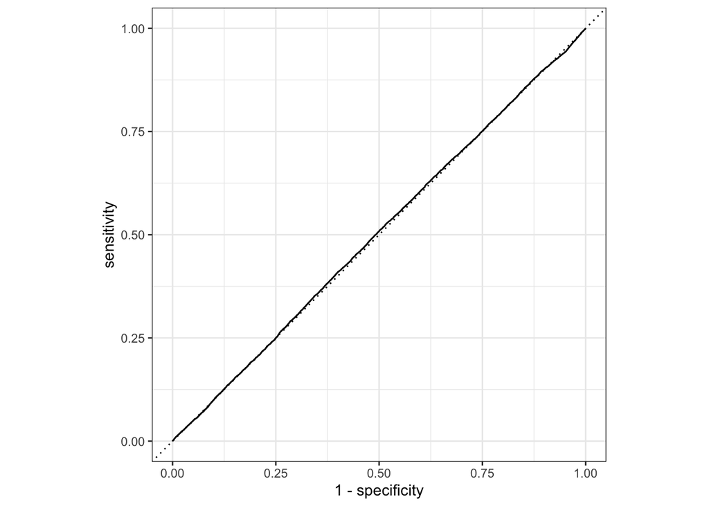

```r
auc_resultRFU <- roc_auc(
  rfu_predictions,
  truth = Heart_Attack,
  .pred_Yes,
  event_level = "second"
)
rfu_predictions %>%
  roc_curve(truth = Heart_Attack, .pred_Yes) %>%
  autoplot()
```

# Discussion

## Model

For all four model, similar approach was used, where the data was portioned into training and testing data. 10- fold cross validation was done on the training data to find the hyperparameters and once the best hyperparameters are known final model is fitted on the entire training data and then its predictive performance is tested on the testing data.

## Model comparison

Based on confusion matrix, it is apparent that logistic regression, random forest and random forest with up sampling performs well to detect people with no heart attack, but perform worst to detect people with the heart attack. The only model which perform fair in detecting people with heart attack is the logistic regression with up-sampling. The Random forest with up sampling did detect one person with heart disease when the results of cross validation was put into confusion matrix. However when fitted final model was tested on the testing data, it failed to detect any person with heart disease.

The sensitivity and specificity of the logistic regression model with Up-sampling is 0.405 and 0.595 respectively, whereas for other models, the specificity is 1 and the sensitivity is zero. Similar difference can be seen in terms of precision, recall, accuracy and F-measures with logistic regression with up sampling performing better in those parameters. To conclude, logistic regression with up- sampling is the best model among the four, even though its performance is also modest. It is possible that other models such as linear discriminant analysis, quadratic discriminant analysis, naives bayes, bayesian additive regression trees or artificial neural network may perform better than our four models.

## Variable importance

### Logistic Regression

The top 5 variables that are found to be most important in logistic regression are Low cholesterol level, poor diet score, low stress level, middle income level and unemployed.

### Logistic Regression with Up-sampling

The top 5 variables that are found to be most important in logistic regression with up-sampling are Previous heart attack, having diabetes, chronic kidney disease and stroke, Medium air pollution exposure.

### Random Forest

The top 5 variables that are found to be most important in random forest are medium air pollution exposure, TCM usage, low air pollution exposure, low cholesterol level and low income level.

### Random Forest with Up-sampling

The top 5 variables that are found to be most important in random forest with up-sampling are family history of CVD, TCM usage, alcohol consumption, obesity and being urban residence.

# Conclusion

Logistic regression with up-sampling performs fair among the four models. Given the low scores of performance metrics for the logistic regression with up-sampling, it is possible that other classification models such as artifical neural networks, linear or quadratic discriminant analysis, or bayesian classification approaches may perform better in classifying people with heart disaese from people without the heart disease.

# References

1. Kasper D, Fauci A, Hauser S, Longo D, Jameson J, Loscalzo J. Harrison’s principles of internal medicine, 19e. New York, NY, USA:: Mcgraw-hill; 2015.
2. Salari N, Morddarvanjoghi F, Abdolmaleki A, Rasoulpoor S, Khaleghi AA, Hezarkhani LA, Shohaimi S, Mohammadi M. The global prevalence of myocardial infarction: a systematic review and meta-analysis. BMC cardiovascular disorders. 2023 Apr 22;23(1):206.